# Machine Learning - Ejercicio Rmarkdown

Mayra Goicochea Neyra

7/11/2019

# 1 Introduction

Suppose that you are an administrator of a university and you want to know the chance of admission of each applicant based on their two exams. You have historical data from previous applicants which can be used as the training data for logistic regression. Your task is to build a classification model that estimates each applicant’s probability of admission in university.

Now, we have understood classification problem that we are going to address. Let us understand the data. In data we have records of previous applicants’ two exams score and label whether applicant got admission or not (1 - if got admission 0 - otherwise).

# 2 Assigment

## 2.1 Test the *TestGradientDescent* function with the training set (*4_1_data.csv*). Obtain the confusion matrix.

First, I load the dataset from file *4_1_data.csv*.

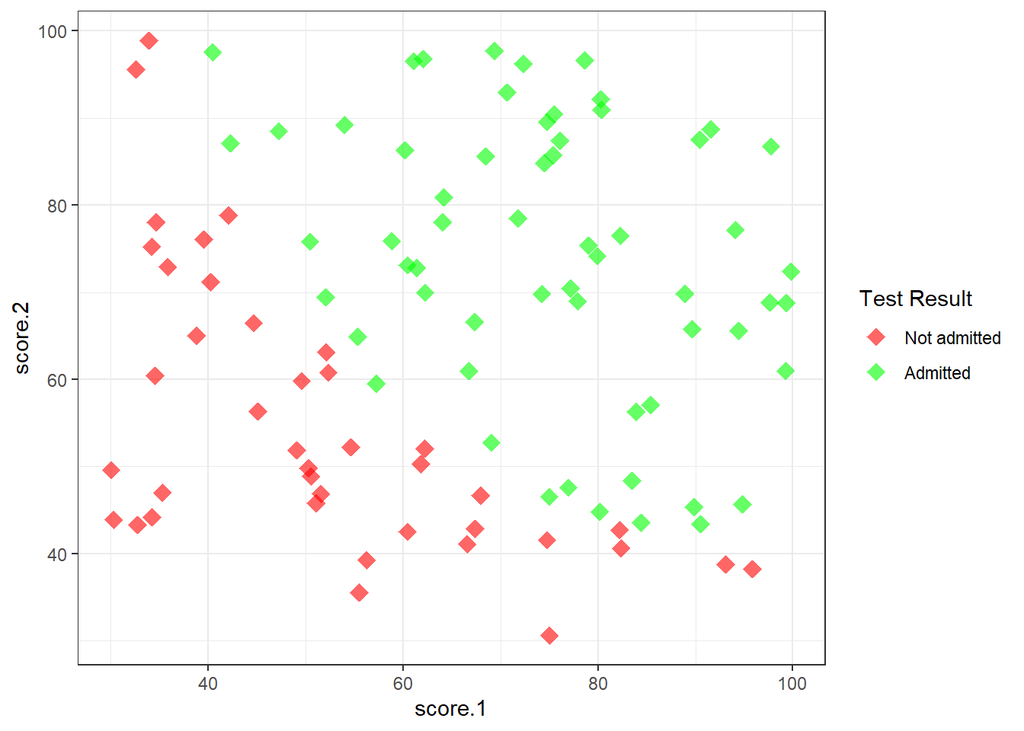

```r
set.seed(777)
#Load data
data <- read.csv("../data/4_1_data.csv")

#Plot
cols <- c("0" = "red","1" = "green")
ggplot(data, aes(x = score.1, y = score.2, colour = as.factor(label))) +
  geom_point(size = 4, shape = 18,alpha = 0.6) +
  scale_colour_manual(values = cols,labels = c("Not admitted", "Admitted"),name = "Test Result") +
  theme_bw()
```

Then, I set predictor and response variables.

```r
#Predictor variables
X <- as.matrix(data[, c(1,2)])

#Add ones to X in the first column (matrix multiplication x b)
X <- cbind(rep(1, nrow(X)), X)

#Response variable
Y <- as.matrix(data$label)
```

So, I set the functions:

### 2.1.1 Sigmoid Function

```r
Sigmoid <- function(x) {
  1 / (1 + exp(-x))
}
```

### 2.1.2 Cost Function

```r
# Ref: https://www.r-bloggers.com/logistic-regression-with-r-step-by-step-implementation-part-2/
# Cost Function
CostFunction <- function(parameters, X, Y) {
  n <- nrow(X)
  g <- Sigmoid(X %*% parameters)
  J <- (1/n) * sum((-Y * log(g)) - ((1 - Y) * log(1 - g)))
  return(J)
}
```

### 2.1.3 TestGradientDescent

```r
TestGradientDescent <- function(iterations = 1200, X, Y) {
  # Initialize (b, W)
  parameters <- rep(0, ncol(X))
  # Check evolution
  print(paste("Initial Cost Function value: ",
              convergence <- c(CostFunction(parameters, X, Y)), sep = ""))

  # updating (b, W) using gradient update

  # Derive theta using gradient descent using optim function
  # Look for information about the "optim" function (there are other options)
  parameters_optimization <- optim(par = parameters, fn = CostFunction, X = X, Y = Y,
                                   control = list(maxit = iterations))
  #set parameters
  parameters <- parameters_optimization$par
  # Check evolution
  print(paste("Final Cost Function value: ",
              convergence <- c(CostFunction(parameters, X, Y)), sep = ""))
  print(paste("Parameters value: ",
              parameters))
 return(parameters)
}
```

### 2.1.4 Confusion Matrix

```r
ConfusionMatrix <- function(X, Y, parameters, cutoff = 0.5) {
  res.tbl <- NA  #First create a null table

 #Then full the table with the results of multiplication of each row with the parameters.
  for (i in 1:nrow(X)) {
      res <- Sigmoid(t(as.numeric(X[i,])) %*% parameters)
      res.tbl <- rbind(res.tbl, res)
   }
  res.tbl <- res.tbl[-1,] # Delete first row because it has missing value

 #Then it creates the matrix validating if each result is greather than cutoff
  matrix <- table(Y, ifelse(res.tbl > cutoff, 1, 0),dnn = c("Actual","Predicted"))
 #Accuracy, Precision, Recall & F1 score
 #First, I get the true values (true positive and true negative)
  true <- matrix[1,1] + matrix[2,2]
 #Accuracy = True values / Total cases
  print(paste("Accuracy: ", true / sum(matrix)))
 #Precision = TP / (TP+FP)
  print(paste("Precision: ", precision <- round(matrix[2,2]/sum(matrix[,2]),4)))
 #Recall = TP / (TP+FN)
  print(paste("Recall: ", recall <- round(matrix[2,2]/sum(matrix[2,]),4)))
 #F1-Score = 2*(Recall*Precision)/(Recall + Precision)
  print(paste("F1 score: ", round(2*(precision*recall)/(precision + recall),4)))
 return(matrix)
}
```

I use **testthat library** to execute the functions and help me to test them making sure everything is alright.

Then I run the functions to get the Confussion Matrix.

```r
test_that("Get Confusion Matrix with Optimal Parameters",{
parameters <- TestGradientDescent(X = X, Y = Y)
matrix <- ConfusionMatrix(X = X, Y = Y, parameters, cutoff = 0.68)
print(matrix)
})
```

```
## [1] "Initial Cost Function value: 0.693147180559945"
## [1] "Final Cost Function value: 0.203497704580909"
## [1] "Parameters value:  -25.1647048465922"
## [2] "Parameters value:  0.206252402073044"
## [3] "Parameters value:  0.201504607481281"
## [1] "Accuracy:  0.88"
## [1] "Precision:  0.9286"
## [1] "Recall:  0.8667"
## [1] "F1 score:  0.8966"
##       Predicted
## Actual  0  1
##      0 36  4
##      1  8 52
```

## 2.2 Obtain a graph representing how the cost function evolves depending of the number of iterations.

First I set a variable of max iterations of tests. Then, create a table of results.

```r
max_iterations <- 500
graph.table <- data.frame(cbind(seq(from = 1, to = max_iterations, by = 1), NA))
names(graph.table) <- c("Iteration", "Cost")
```

With a for iteration, I get the optimal parameters of Cost Function and the values of Cost Function.

```r
parameters <- rep(x = 0, times = 3)
iterations <- 0
for (i in 1:max_iterations) {
  opt.parameters <- optim(par = parameters, fn = CostFunction, X = X, Y = Y,
                                   control = list(maxit = iterations))
  iterations <- iterations + 1
  graph.table[i, 2] <- CostFunction(opt.parameters$par, X, Y)
}
```

Then, I make a graph of the results.

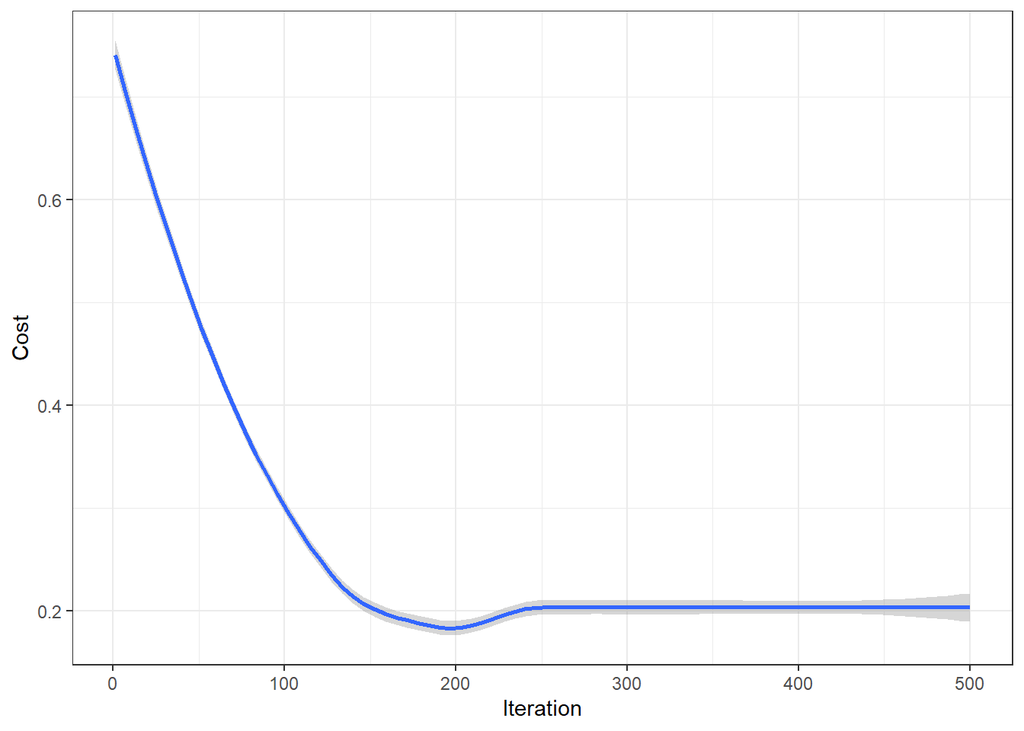

```r
ggplot(data = graph.table, aes(x = Iteration, y = Cost)) +
  geom_smooth(se = TRUE) +
  theme_bw()
```